# Project log reporting

Aitor Gonzalez

26/10/2021

The main purpose of this document consists in the creation of a guideline so that in the long run  
all the processes that gives issues can be registered in order to identify all the issues along the project and how they were solved if similar problems are encountered in the future, they can be identified and solved much more easily.

In addition, it allows for a certain degree of control of the procediments.

## “2021-10-20 11:00 CEST”

- The Github project was setted in the repository https://github.com/DataMirai/Sensorama which posses:
  - had the documentation necessary in a chemical level and few R libraries to do the job
  - The file **Original_odor_relations.JSON** file in JSON format. Identified an **issue** with the import of this file to R

## “2021-10-26 12:30 CEST”

1. Solved the problem to import the data **Original_odor_relations.JSON**: **wrongly parsed**.
- R does not reported the line in which there was a mistake, so was not possible to identify *in site* the nature of the issue. only points that trails gargabe.

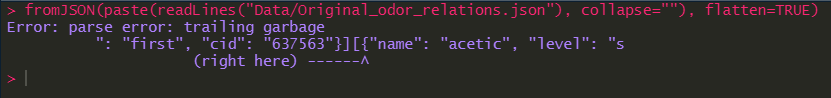

- Used https://codebeautify.org/jsonviewer as a tool to track an arrange the JSON data, identified the problem in **line 18282**, there were ][ symbols placed in the middle of the JSON structure.
- The data was no duplicated, it seems that only misstracked something in the process of its creation.
2. Added the **compounds.csv** dataset to the environment, linked by the *cid* variable

## “2021-10-27 17:14 CEST”

It was decided to use the package **ChemmineR** to extract all the fingerprints from the molecules

## “2021-10-29 12:31 CEST”

identified conflicting molecules with the ChemmineR methodology. in concrete molecules with $cid = ("222","14923", "25519")$, which corresponds to Nitrogen and Amonia derivates. To solve the conflict they has been removed.

## 2021-11-03 20:58:17 CET

There where issues about getting the fingerprints with **BiocManager, ChemmineR and ChemmineOB** packages. To solve these issues, it was included the use of the **rcdk** package, which is different than the previous ones to extract fingerprints and molecules descriptors.

To use de rcdk package it is required to use **Java** in the computer, so install Java from other sources like [https://www.oracle.com/java/technologies/downloads/]{https://www.oracle.com/java/technologies/downloads/}

## “2021-11-06 01:47:11 CET”

The tibble data format that has been created all along can be exportable in JSON fromat. A security copy of the process has been saved in *Data/Sensorama_JSON.json*, If it was necessary to export or anything else, can be recovered using in R environment:

```r
#fromJSON("Data/Sensorama_JSON.json") %>%
#  as_tibble()
```

Furthermore, the data has been arranged in script 1 to be parallelize data management phase. The method used to construct the special structures sdf and parsed.smiles forms are paralelized with the **future_map** from the **furrr** library. Further documentation of the method can be found here {http://zevross.com/blog/2019/02/12/dramatically-speed-up-your-r-purrr-functions-with-the-furrr-package/}